# How leaders structure a field? A history of the trajectories and interactions of the International Association for Feminist Economics presidents?

Technical Appendix

Authors

Affiliations

Rebeca Gomez Betancourt

Université Lumière Lyon-2

Camila Orozco Espinel

Université de Reims Champagne-Ardennes

Anthony Rebours

Université Paris 8

# Introduction

This document is the technical appendix of the article “A History of IAFFE Presidents’ Trajectories and Cognitive Interactions” written by Rebeca Gomez Betancourt, Camila Orozco Espinel and Anthony Rebours. For questions and requests concerning the part of the project contained in this appendix please email **Anthony Rebours**.

In the article we followed the trajectories of the 26 first presidents of the International Association for Feminist Economics (IAFFE). Some of the results included in this appendix are reproduced in the article while others are only available here. In addition to the results we also provide the codes we used for these results.

# Prosopographic analysis and individuals trajectories of IAFFE leaders

```r
# Load prosopographic database

prosopo <-
  import(
    here(
      "data",
      "prosopographic_analysis",
      "prosopography.csv"
    ),
    encoding = "Latin-1"
  )
```

The first database contains prosopographical information about the first 26 IAFFE presidents, that is a collective biography aimed at uncovering sharing characteristics between selected individuals (Svorenčík 2018). For our study, we have manually collected data from different sources (CVs, interviews, [**IAFFE website**](https://www.iaffe.org/)…) about each of them. **Table 1** provides detailed information we collected about their personal and professional trajectories and **Table 2** presents information about their administrative positions in the board of IAFFE or in the journal of the association, *Feminist Economics*.

## Formation and geographical origins of IAFFE presidents

**Table 1.** IAFFE presidents careers informations

```r
# Table layout

prosopo %>%
  select(
    "Presidents" = name,
    "Birth" = birthdate,
    "Citizenship" = country_of_birth,
    "Formation" = ph_d_university,
    "Academic position" = academic_position_university_department,
    "Research Topics" = research_topics
  ) %>%
  flextable() %>%
  bold(bold = TRUE, part = "header") %>%
  theme_vanilla() %>%
  fontsize(size = 9, part = "all") %>%
  width(j = 1, width = 0.9) %>%
  width(j = 2, width = 0.5) %>%
  width(j = 3, width = 0.7) %>%
  width(j = 4:5, width = 1.5) %>%
  width(j = 6, width = 1)
```

| Presidents | Birth | Citizenship | Formation | Academic position | Research Topics |
| --- | --- | --- | --- | --- | --- |
| J.A. Shackelford | 1946 | USA | University of Kentucky / 1974 / Economics | Bucknell University / Economics | Feminist Economics |
| M.A. Ferber | 1923 - 2013 | USA | University of Chicago / 1954 / Economics | University of Illinois, Urbana-Champaign / Economics | Economics, family |
| M.H. Strober | 1940 | USA | MIT / 1969 / Economics | Stanford University / School of Education | Labor, women in economics |
| B.R. Bergmann | 1927 - 2015 | USA | Harvard University / 1959 / Economics | University of Maryland / American University / Economics | Discrimination, methodology |
| R.D. Sharp | 1953 | Australian | University of Sydney / 1997 / Economics | University of South Australia / Economics | Social policies, empowerment |
| J. Humphries | 1948 | UK | Cornell University / 1973 / Economics | All Souls College, University of Oxford / Economic History | Economic history, growth, development |
| N. Folbre | 1952 | USA | University of Massachusetts Amherst / 1979 / Economics | University of Massachusetts Amherst / Economics | Family economics, non-market work, care |
| L. Benería | 1937 | Spain | Columbia University / 1975 / Economics | Cornell University / City and Regional Planning | Latin America development, migrations |
| B. Agarwal | 1951 | India | University of Delhi / 1978 / Economics | University of Manchester / School of Environment, Education and Development | Development economics, peasant studies |
| R.L. Bartlett | 1947 | USA | Michigan State University / 1974 / Economics | Denison University / Economics and Queer Studies | Queer economics, race |
| E. Kuiper | 1960 | Netherlands | University of Amsterdam / 1996 / Economics | SUNY New Paltz / Economics | Feminist philosophy, ""herstory"" |
| M.L. MacDonald | 1950 | Canada | Boston College / 1983 / Economics | St Mary's University / Economics | Labor market, care |
| C.A. Conrad | 1955 | USA | Stanford University / 1982 / Economics | Pomona College / Economics | Race, gender |
| S.F. Himmelweit | 1948 | UK | Cambridge University / / Economics | Open University / Economics | Care, reproduction |
| V.E. Barriteau | 1954 | Barbados | Howard University / 1994 / Political Sciences | University of the West Indies / Gender and Public Policy | Gender in Carribean |
| S. Seguino | around 1956 | USA | American University / 1994 / Economics | University of Vermont / Economics | Income distribution in Asia |
| R.C. Todaro | 1941 - 2022 | Chile | University of Pennsylvania / / Regional Science | Women's Study Center (Chile) | Gender in Latin America |
| A. Stark | 1946 | Sweden | Stockholm University / 1973 / Business Administration | Dalarna University | Social accounting, care |
| Y.V.D.M. Rodgers | 1966 | Netherlands | Harvard University / 1993 / Economics | Rutgers University / Woman's and Gender Studies | Labor, development |
| A. Girón | 1951 | Mexico | National Autonomous University of Mexico (UNAM) / 1989 / Latin American Studies | Institute for Economic Research (UNAM) / Economics | Finance and women in Latin America |
| S. Özar | 1955 | Turkey | Vienna University of Economics and Business / 1990 / Economics | Bogaziçi University / Economics | Labor market, informal sector |
| J.P. Jacobsen | 1961 | USA | Stanford University / 1991 / Economics | Hobart & William Smith Colleges / Economics | Discrimination, migration |
| S. Berger | 1942 | Argentina | University of Buenos Aires / / Political economy (Master) | Latin American Social Sciences Institute (FLACSO) | Latin America, labor market |
| N. Kabeer | 1950 | India | London School of Economics / 1985 / Economics | London School of Economics and Political Science / Gender Institute | Gender, international development |
| C.R. Doss | 1962 | UK | University of Minnesota / 1996 / Economics | Oxford University / International Development | Development economics, gender, assets |
| R. Balakrishnan | 1959 | India | Rutgers University / 1990 / Economics | Rutgers University / Women’s and Gender Studies / Center for Women's Global Leadership | Macroeconomic policies, human rights |

```r
#  Re-arranging data into different periods

prosopo <-
  prosopo %>%
  separate(
    iaffe_presidency,
    "iaffe_presidency",
    sep = "-"
  ) %>%
  mutate(iaffe_presidency = as.integer(iaffe_presidency)) %>%
  mutate(Periods = case_when(
    between(iaffe_presidency, 1993, 2002) ~ "1993-2002",
    between(iaffe_presidency, 2003, 2012) ~ "2003-2012",
    between(iaffe_presidency, 2013, 2019) ~ "2013-2019")
    )

# Rearranging formation variable
prosopo <-
  prosopo %>%
  separate(
    ph_d_university,
    c(
      "Universities",
      "Date",
      "Disciplines"
    ),
    sep = "/"
  )
```

**Figure A1.** Geographical origins of IAFFE presidents

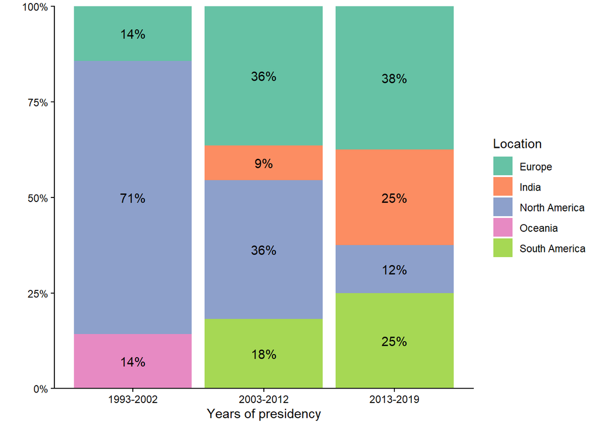

```r
# Plot figure

prosopo %>%
  mutate(
    Location = recode(
    country_of_birth,
    "Argentina" = "South America",
    "Australian" = "Oceania",
    "Barbados" = "South America",
    "Canada" = "North America",
    "Chile" = "South America",
    "Mexico" = "South America",
    "Netherlands" = "Europe",
    "Sweden" = "Europe",
    "Spain" = "Europe",
    "Turkey" = "Europe",
    "UK" = "Europe",
    "USA" = "North America"
    )
  ) %>%
  count(Periods, Location) %>%
  group_by(Periods) %>%
  mutate(
    proportion = n/sum(n),
    proportion_label = paste0(
      round(proportion * 100), "%"
    )
  ) %>%
  ggplot(
    aes(
      x = Periods,
      y = proportion,
      fill = Location,
      label = proportion_label
    )
  ) +
  geom_col() +
  theme_classic() +
  scale_y_continuous(
    expand = c(0, 0),
    labels = label_percent()
  ) +
  scale_fill_brewer(palette = "Set2") +
  labs(
    x = "Years of presidency",
    y = ""
  ) +
  geom_text(position = position_stack(vjust = 0.5))
```

**Figure A2.** Geographical graduations of IAFFE presidents

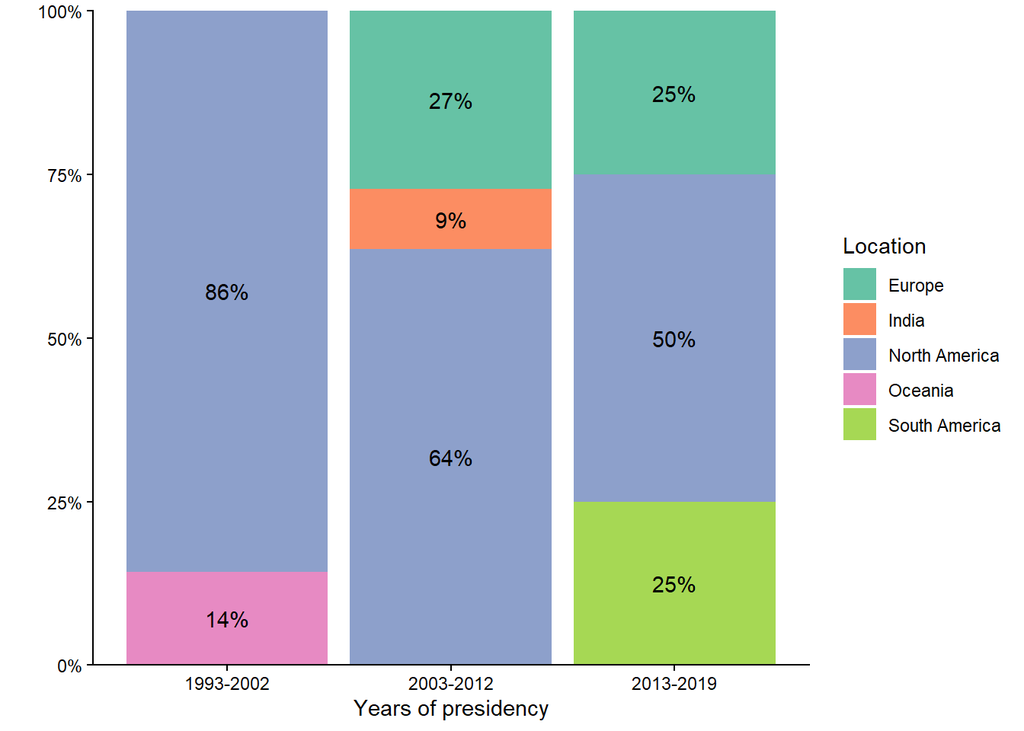

```r
# Plot figure

prosopo %>%
  mutate(
    Location = recode(
      country_of_formation,
      "Argentina" = "South America",
      "Australia" = "Oceania",
      "Austria" = "Europe",
      "Mexico" = "South America",
      "Netherlands" = "Europe",
      "Sweden" = "Europe",
      "UK" = "Europe",
      "USA" = "North America"
    )
  ) %>%
  count(Periods, Location) %>%
  group_by(Periods) %>%
  mutate(
    proportion = n/sum(n),
    proportion_label = paste0(
      round(proportion * 100), "%"
    )
  ) %>%
  ggplot(
    aes(
      x = Periods,
      y = proportion,
      fill = Location,
      label = proportion_label
    )
  ) +
  geom_col() +
  theme_classic() +
  scale_y_continuous(
    expand = c(0, 0),
    labels = label_percent()
  ) +
  scale_fill_brewer(palette = "Set2") +
  labs(
    x = "Years of presidency",
    y = ""
  ) +
  geom_text(position = position_stack(vjust = 0.5))
```

## Administrative charges

**Table 2.** IAFFE presidents administrative positions in the field

```r
# Table layout

prosopo %>%
  select(
    "Presidents" = name,
    "Board of Directors" = iaffe_functions,
    "Years on Board" = years_at_iaffe,
    "Journal Feminist Economics" = fe_functions
  ) %>%
  flextable() %>%
  theme_vanilla() %>%
  padding(padding.bottom = 3, part = "all") %>%
  bold(bold = TRUE, part = "header") %>%
  fontsize(size = 9, part = "all") %>%
  width(j = 1, width = 1) %>%
  width(j = 2, width = 2.5) %>%
  width(j = 3, width = 0.6) %>%
  width(j = 4, width = 2.5)
```

| Presidents | Board of Directors | Years on Board | Journal Feminist Economics |
| --- | --- | --- | --- |
| J.A. Shackelford | Founding member, President (1993-1995), Executive Secretary and Treasurer (1994-2005) | 12 | Associate Editor and Section Editor (1994-2004), Editorial Board (2006-2012) |
| M.A. Ferber | Founding member, President (1995-1997), Board member (1997-1999) | 4 | Associate Editor (1994-2008), Editorial Board (2009-2013) |
| M.H. Strober | President (1997-1999), Past President (1999-2000) | 3 | Associate Editor (1994- 2008), Editorial Board (2008-present) |
| B.R. Bergmann | Founding member, Board member (1995-1999), President (1999-2000) | 5 | Associate Editor and Section Editor (1994-2008) |
| R.D. Sharp | Board member (1995-1998, 1999-2000), President (2000-2001), Past President (2001-2002) | 6 | International Editorial Advisory Committee (1994-1999) |
| J. Humphries | Board member (2000-2001), President (2001-2002), Past President (2002-2003) | 3 | Associate Editor (1995-present) |
| N. Folbre | Founding member, Board member (1995-1997, 2001-2002, 2003-2004), President (2002-2003) | 5 | Associate Editor (1994-2012), Editorial Board (2012-present) |
| L. Benería | Founding member, Board member (1995-1997, 2002-2003, 2004-2005), President (2003-2004), Past President (2004-2005) | 5 | Associate Editor (2000-2017), Editorial Board (2017-present) |
| B. Agarwal | Board member (1995-2001, 2003-2004), President (2004-2005), Past President (2005-2006) | 9 | Associate Editor (1994-2012), Editorial Board (2012-present) |
| R.L. Bartlett | Founding member, Board member (1995-1997, 2003-2004), President (2005-2006) | 4 | Editorial Advisory Board (1995-2001) |
| E. Kuiper | Founding member, Board Member (1995-1998, 1999-2001, 2005-2006), President (2006-2007), Past-President (2007-2008) | 9 | Associate Editor (1997-2011) |
| M.L. MacDonald | Vice-president (1995-1997), President-Elected (2006-2007), President (2007-2008), Past-President (2008-2009) | 5 | Associate Editor (1997-2011), Editorial Board (2011–2018), Book Review Editor (1997-2003) |
| C.A. Conrad | Board member (2004-2007), President-Elected (2007-2008), President (2008-2009), Past President (2009-2010) and Chair of the Board (2015-2018) | 9 | Associate Editor (2002-2010), Editorial Board (2010-present) |
| S.F. Himmelweit | Board member (1997-2000), President-Elected (2008-2009), President (2009-2010), Past President (2010-2011) | 6 | Associate Editor (1996-2012) |
| V.E. Barriteau | Board member (2004-2007), President-Elected (2009-2010), President (2010-2011), Past President (2011-2012) | 6 | No |
| S. Seguino | Board member (2009-2010), President (2010-2011), Past President (2011-2012) | 3 | Associate Editor (2004-present) |
| R.C. Todaro | Board member (2006-2010), President-Elected (2010-2011), President (2011-2012) | 6 | Editorial Board (2005-2013) |
| A. Stark | Board member (2001-2004, 2005-2011), President-Elected (2011-2012), President (2012-2013) | 11 | Associate Editor (2003-2005) |
| Y.V.D.M. Rodgers | Board member (2008-2011), President-Elected (2012-2013), President (2013-2014), Past-President (2014-2015) | 6 | Associate Editor (2005-Present) |
| A. Girón | Board member (2001-2004, 2005-2006), Vice-president (2006-2008), President-Elected (2013-2014), President (2014-2015), Past President (2015-2016) | 9 | No |
| S. Özar | Board member (2002-2005), (2006-2008), Vice-president (2005-2006), President-Elected (2014-2015), President (2015-2016), Past President (2016-2017) | 9 | No |
| J.P. Jacobsen | Founding Member, Board member (2011-2015), President-Elected (2015-2016), President (2016-2017), Past President (2017-2018) | 7 | Associate Editor (2004-2010), Editorial Board (2010-present) |
| S. Berger | Board member (2011-2012, 2013-2016), President-Elected (2016-2017), President (2017-2018), Past President (2018-2019) | 7 | No |
| N. Kabeer | Board member(2014-2016), President-Elected (2017-2018), President (2018-2019), Past President (2019-2020) | 5 | Associate Editor (2005-Present) |
| C.R. Doss | President-Elected (2018-2019), President (2019-2020), Past President (2020-2021) | 3 | Associate Editor (2004-2013), Editorial Board (2014-present), Book Review Editor (2005-2012) |
| R. Balakrishnan | Founding Member, Board member (1997-2000, 2011-2014), President-elected (2019-2020), President (2020-2021), Past-president (2021-2022) | 9 | No |

# Publication analysis using Web of Science databases

```r
# Load WoS publications data

wos_publications <-
  import(
  here(
    "data",
    "publication_analysis",
    "wos_publications2.csv"
  ),
  encoding = "Latin-1"
)

# Re-formating authors'name

wos_publications <-
  wos_publications %>%
  separate(
    author,
    into = c("name", "firstname"),
    sep = "-"
  ) %>%
  mutate(name = str_to_title(name)) %>%
  separate_wider_regex(
    firstname,
    patterns = c(
      initial1 = "[[A-Z]]+",
      "",
      initial2 = "[[A-Z]]+"
    ),
    too_few = "align_start"
  ) %>%
  mutate(
    initial1 = str_c(initial1, "", "."),
    initial2 = str_c(initial2, "", ".")
  ) %>%
  unite(
    firstname,
    c("initial1", "initial2"),
    sep = "",
    na.rm =TRUE
  ) %>%
  unite(
    author,
    c("firstname", "name"),
    sep = " "
  )

# Re-formating title and journal

wos_publications <-
  wos_publications %>%
  mutate(journal = str_to_title(journal)) %>%
  mutate(title = str_to_title(title))
```

The second database includes all the papers published by the 26 past presidents of IAFFE that we collected from the Clarivate Analytics Web of Science (WoS) databases. To track their papers we tried any possible combinations of presidents’ names and first names. For instance, in the case of Jean Shackelford we searched for publications in which one of the authors was either “Shackelford-JA” or “Shackelford-J”.

This first search was done in all journals indexed by WoS and allow us to collect a total of **11 400** publications. However, given that a great majority of these papers were written by homonyms and not the authors we selected, we choose to restrict our search to articles published in journals from social sciences and humanities fields. It is important to note here that the data we had access to had been processed by the [**Observatoire des sciences et technologies**](https://www.ost.uqam.ca/) which assigns each journal in WoS to a unique field of research. Their classification is based on the one used by the US National Science Foundation (National Science Board, 2006, Appendix table 5-39, can be find [**here**](https://files.eric.ed.gov/fulltext/ED490852.pdf)).

After this second query, the number of articles has decreased to **a bit more than 2000**. All these articles were then manually inspected to exclude those written by homonyms, leaving us with a total of **784** publications including academic papers but also book reviews, replays, corrections, interviews, editorials, prefaces, magazine articles, congratulation notes and opinion columns published between 1966 and 2019. The **figure** below illustrates the evolution of the number of documents published per years in our corpus while the **table** shows in details the distribution of these publications among the 26 IAFFE presidents.

**Figure A3.** Number of documents per years (The curve is smoothed using local polynomial regression fitting)

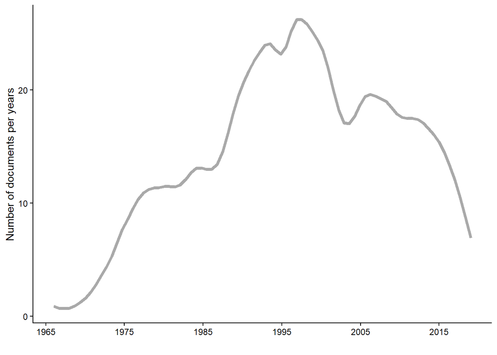

```r
# Plot figure

wos_publications %>%
  select(
    code,
    year,
    research_pub
  ) %>%
  distinct() %>%
  group_by(year) %>%
  count(year) %>%
  ggplot(aes(x = year, y = n)) +
  geom_smooth(
    se = FALSE,
    span = .3,
    color = "darkgrey",
    size = 1.5) +
  theme_classic() +
  scale_x_continuous(breaks = seq(
    from = 1965,
    to = 2020,
    by = 10
    )) +
  xlab("") +
  ylab("Number of documents per years")
```

**Table 3.** Total number of publications (Source Web of Science)

```r
# Creation of table summarizing individuals publications data

pub_tab <-
  wos_publications %>%
  group_by(author) %>%
  summarise(
    total = n(),
    research_articles = sum(research_pub == "TRUE", na.rm = T),
    other_publications = sum(research_pub == "FALSE", na.rm = T),
    from_1993 = percent(sum(year>=1993, na.rm = T)/total, 0.1),
    "in FE" = percent(
      sum(journal == "FEMINIST ECONOMICS", na.rm = T)/total, 0.1)
    )

# Add a new variable about first and last published document per authors

pub_tab <- wos_publications %>%
  group_by(author) %>%
  mutate(first_last = paste0(min(year), "-", max(year))) %>%
  select(author, first_last) %>%
  right_join(pub_tab, by = "author")%>%
  distinct()

# Table settings

pub_tab %>%
  arrange(desc(total)) %>%
  select(
    author,
    total,
    research_articles,
    other_publications,
    everything()) %>%
  rename(
    "Authors" = author,
    "Total" = total,
    "Research Articles" = research_articles,
    "Other Publications" = other_publications,
    "First - Last" = first_last,
    "From 1993" = from_1993) %>%
  adorn_totals(
    rows = c(
      "Total",
      "Research Articles",
      "Other Publications"
    ),
    fill = "--") %>%
  flextable() %>%
  fontsize(size = 9, part = "all") %>%
  align(align = "right", j = c(2:7), part = "all") %>%
  bold(bold = TRUE, part = "header") %>%
  bold(bold = TRUE, part = "body", i = 25) %>%
  hline(i = 24) %>%
  padding(padding.bottom = 3, part = "all") %>%
  set_table_properties(width = 1, layout = "autofit")
```

| Authors | Total | Research Articles | Other Publications | First - Last | From 1993 | in FE |
| --- | --- | --- | --- | --- | --- | --- |
| N. Folbre | 93 | 56 | 37 | 1980-2018 | 63.4% | 0.0% |
| K.J. Humphries | 89 | 41 | 48 | 1976-2019 | 78.7% | 0.0% |
| B.R. Bergmann | 88 | 39 | 49 | 1966-2013 | 50.0% | 0.0% |
| M.A. Ferber | 83 | 50 | 33 | 1972-2011 | 34.9% | 0.0% |
| N. Kabeer | 51 | 42 | 9 | 1985-2018 | 88.2% | 0.0% |
| J.P. Jacobsen | 40 | 23 | 17 | 1986-2018 | 85.0% | 0.0% |
| B. Agarwal | 38 | 37 | 1 | 1980-2018 | 68.4% | 0.0% |
| C.R. Doss | 38 | 36 | 2 | 1994-2019 | 100.0% | 0.0% |
| Y.M. Rodgers | 36 | 29 | 7 | 1993-2018 | 100.0% | 0.0% |
| M.H. Strober | 35 | 20 | 15 | 1972-2014 | 34.3% | 0.0% |
| J.A. Shackelford | 29 | 6 | 23 | 1980-2001 | 13.8% | 0.0% |
| L. Beneria | 27 | 17 | 10 | 1976-2015 | 55.6% | 0.0% |
| R.L. Bartlett | 24 | 24 | 0 | 1977-2005 | 37.5% | 0.0% |
| C.A. Conrad | 22 | 10 | 12 | 1984-2010 | 77.3% | 0.0% |
| A.G. Giron | 21 | 15 | 6 | 1976-2018 | 47.6% | 0.0% |
| S. Seguino | 21 | 20 | 1 | 1989-2018 | 95.2% | 0.0% |
| S.F. Himmelweit | 18 | 15 | 3 | 1976-2013 | 77.8% | 0.0% |
| R.D. Sharp | 17 | 15 | 2 | 1990-2016 | 94.1% | 0.0% |
| M.L. Macdonald | 13 | 10 | 3 | 1991-2014 | 92.3% | 0.0% |
| A. Stark | 6 | 4 | 2 | 1986-2005 | 66.7% | 0.0% |
| R. Balakrishnan | 3 | 3 | 0 | 2007-2012 | 100.0% | 0.0% |
| E. Kuiper | 3 | 3 | 0 | 2004-2007 | 100.0% | 0.0% |
| V.E. Barriteau | 2 | 2 | 0 | 1989-1998 | 50.0% | 0.0% |
| S. Ozar | 2 | 2 | 0 | 2008-2013 | 100.0% | 0.0% |
| Total | 799 | 519 | 280 | -- | -- | -- |

## Coauthoring

```r
# Load data about coauthors

wos_coauth <-
  import(
  here(
    "data",
    "publication_analysis",
    "wos_coauth2.csv"
  ),
  encoding = "Latin-1"
)
```

**Table A1.** Total coauthored papers

```r
# Table layout

wos_coauth %>%
  get_dupes(-author) %>%
  count(author) %>%
    filter(
      author == "AGARWAL-B" | author == "BALAKRISHNAN-R" |
      author == "BARRITEAU-VE" | author == "BARTLETT-RL" |
      author ==  "BENERIA-L" | author == "BERGER-S" |
      author == "BERGMANN-BR" | author == "CONRAD-CA" |
      author == "DOSS-CR" | author == "FERBER-MA" |
      author == "FOLBRE-N" | author == "GIRON-AG" |
      author == "HIMMELWEIT-SF" | author == "HUMPHRIES-KJ" |
      author == "JACOBSEN-JP" | author == "KABEER-N" |
      author == "KUIPER-E" | author == "MACDONALD-ML" |
      author == "OZAR-S" | author == "RODGERS-YM" |
      author == "SEGUINO-S" | author == "SHACKELFORD-JA" |
      author == "SHARP-RD" | author == "STARK-A" |
      author =="STROBER-MH" | author == "TODARO-RC"
    ) %>%
  arrange(desc(n)) %>%
  flextable() %>%
  fontsize(size = 9, part = "all") %>%
  set_table_properties(width = 1, layout = "autofit") %>%
  bold(bold = TRUE, part = "header") %>%
  padding(padding.bottom = 3, part = "all")
```

| author | n |
| --- | --- |
| FERBER-MA | 35 |
| HUMPHRIES-KJ | 29 |
| FOLBRE-N | 26 |
| DOSS-CR | 25 |
| BARTLETT-RL | 19 |
| STROBER-MH | 16 |
| KABEER-N | 15 |
| SHARP-RD | 15 |
| BERGMANN-BR | 14 |
| JACOBSEN-JP | 14 |
| BENERIA-L | 8 |
| HIMMELWEIT-SF | 8 |
| SEGUINO-S | 8 |
| CONRAD-CA | 6 |
| GIRON-AG | 6 |
| MACDONALD-ML | 5 |
| SHACKELFORD-JA | 5 |
| AGARWAL-B | 4 |
| BALAKRISHNAN-R | 3 |
| KUIPER-E | 3 |
| OZAR-S | 2 |
| STARK-A | 2 |
| BARRITEAU-VE | 1 |

**Table A2.** Articles with at least two IAFFE presidents as coauthors

```r
# Table Layout

wos_publications %>%
  mutate(year = as.character(year)) %>%
  get_dupes(-author) %>%
  select(
    "Authors" = author,
    "Year" = year,
    "Journal" =  journal,
    "Document Title" = title) %>%
  flextable() %>%
  fontsize(size = 9, part = "all") %>%
  set_table_properties(width = 1, layout = "autofit") %>%
  bold(bold = TRUE, part = "header") %>%
  padding(padding.bottom = 3, part = "all")
```

| Authors | Year | Journal | Document Title |
| --- | --- | --- | --- |
| R.L. Bartlett | 1999 | Feminist Economics | Toward A Feminist Pedagogy In Economics |
| J.A. Shackelford | 1999 | Feminist Economics | Toward A Feminist Pedagogy In Economics |
| N. Folbre | 2000 | Feminist Economics | Introduction - Children And Family Policy: A Feminist Issue |
| S.F. Himmelweit | 2000 | Feminist Economics | Introduction - Children And Family Policy: A Feminist Issue |
| L. Beneria | 2000 | Feminist Economics | Globalization And Gender - Introduction |
| M.L. Macdonald | 2000 | Feminist Economics | Globalization And Gender - Introduction |
| B. Agarwal | 2003 | Feminist Economics | Exploring The Challenges Of Amartya Sen's Work And Ideas: An Introduction |
| K.J. Humphries | 2003 | Feminist Economics | Exploring The Challenges Of Amartya Sen's Work And Ideas: An Introduction |
| B. Agarwal | 2003 | Feminist Economics | Continuing The Conversation |
| K.J. Humphries | 2003 | Feminist Economics | Continuing The Conversation |
| S.F. Himmelweit | 2004 | Feminist Economics | The Dilemmas Of Lone Motherhood: Key Issues For Feminist Economics |
| K.J. Humphries | 2004 | Feminist Economics | The Dilemmas Of Lone Motherhood: Key Issues For Feminist Economics |
| B.R. Bergmann | 2004 | Feminist Economics | Lone Mothers: What Is To Be Done? |
| S.F. Himmelweit | 2004 | Feminist Economics | Lone Mothers: What Is To Be Done? |
| M.A. Ferber | 2004 | Feminist Economics | Feminist And Economic Inquiry In Central And Eastern Europe |
| E. Kuiper | 2004 | Feminist Economics | Feminist And Economic Inquiry In Central And Eastern Europe |
| N. Folbre | 2005 | Feminist Economics | Explorations Gender And Aging: Cross-National Contrasts |
| A. Stark | 2005 | Feminist Economics | Explorations Gender And Aging: Cross-National Contrasts |
| N. Folbre | 2005 | Feminist Economics | Introduction: Gender And Aging |
| A. Stark | 2005 | Feminist Economics | Introduction: Gender And Aging |
| K.J. Humphries | 2006 | Feminist Economics | Explorations The Status Of Women Economists |
| J.P. Jacobsen | 2006 | Feminist Economics | Explorations The Status Of Women Economists |
| C.A. Conrad | 2008 | Feminist Economics | The Aids Epidemic: Challenges For Feminist Economics |
| C.R. Doss | 2008 | Feminist Economics | The Aids Epidemic: Challenges For Feminist Economics |
| Y.M. Rodgers | 2009 | Feminist Economics | Feminist Economics Of Inequality, Development, And Growth |
| S. Seguino | 2009 | Feminist Economics | Feminist Economics Of Inequality, Development, And Growth |
| L. Beneria | 2012 | Feminist Economics | Gender And International Migration: Globalization, Development, And Governance |
| N. Kabeer | 2012 | Feminist Economics | Gender And International Migration: Globalization, Development, And Governance |
| N. Kabeer | 2016 | Feminist Economics | 1 Voice And Agency: Where Are We Now? |
| Y.M. Rodgers | 2016 | Feminist Economics | 1 Voice And Agency: Where Are We Now? |

**Table A3.** Most coauthored IAFFE presidents

```r
# Table layout

wos_coauth %>%
  coauth_network(
    authors = "author",
    articles = "code",
    method = "full_counting") %>%
  select(from, to, weight) %>%
   filter(c(from == "AGARWAL-B" | from == "BALAKRISHNAN-R" |
           from == "BARRITEAU-VE" | from == "BARTLETT-RL" |
           from ==  "BENERIA-L" | from == "BERGER-S" |
           from == "BERGMANN-BR" | from == "CONRAD-CA" |
           from == "DOSS-CR" | from == "FERBER-MA" |
           from == "FOLBRE-N" | from == "GIRON-AG" |
           from == "HIMMELWEIT-SF" | from == "HUMPHRIES-KJ" |
           from == "JACOBSEN-JP" | from == "KABEER-N" |
           from == "KUIPER-E" | from == "MACDONALD-ML" |
           from == "OZAR-S" | from == "RODGERS-YM" |
           from == "SEGUINO-S" | from == "SHACKELFORD-JA" |
           from == "SHARP-RD" | from == "STARK-A" |
           from =="STROBER-MH" | from == "TODARO-RC") &
            c(to == "AGARWAL-B" | to == "BALAKRISHNAN-R" |
           to == "BARRITEAU-VE" | to == "BARTLETT-RL" |
           to ==  "BENERIA-L" | to == "BERGER-S" |
           to == "BERGMANN-BR" | to == "CONRAD-CA" |
           to == "DOSS-CR" | to == "FERBER-MA" |
           to == "FOLBRE-N" | to == "GIRON-AG" |
           to == "HIMMELWEIT-SF" | to == "HUMPHRIES-KJ" |
           to == "JACOBSEN-JP" | to == "KABEER-N" |
           to == "KUIPER-E" | to == "MACDONALD-ML" |
           to == "OZAR-S" | to == "RODGERS-YM" |
           to == "SEGUINO-S" | to == "SHACKELFORD-JA" |
           to == "SHARP-RD" | to == "STARK-A" |
           to =="STROBER-MH" | to == "TODARO-RC")) %>%
  arrange(desc(weight)) %>%
  flextable() %>%
  fontsize(size = 9, part = "all") %>%
  set_table_properties(width = 1, layout = "autofit") %>%
  width(width = 3) %>%
  bold(bold = TRUE, part = "header") %>%
  padding(padding.bottom = 3, part = "all")
```

| from | to | weight |
| --- | --- | --- |
| HUMPHRIES-KJ | AGARWAL-B | 2 |
| STARK-A | FOLBRE-N | 2 |
| SHACKELFORD-JA | BARTLETT-RL | 1 |
| HIMMELWEIT-SF | FOLBRE-N | 1 |
| MACDONALD-ML | BENERIA-L | 1 |
| HUMPHRIES-KJ | HIMMELWEIT-SF | 1 |
| HIMMELWEIT-SF | BERGMANN-BR | 1 |
| KUIPER-E | FERBER-MA | 1 |
| JACOBSEN-JP | HUMPHRIES-KJ | 1 |
| DOSS-CR | CONRAD-CA | 1 |
| KABEER-N | BENERIA-L | 1 |

## Publication venues

```r
# Creation of table summarizing main publication venues

main_journals <-
  wos_publications %>%
  select(-author) %>%
  distinct() %>%
  group_by(journal) %>%
  summarise(
    total = n(),
    other_publications = sum(research_pub == "FALSE", na.rm = T),
    research_articles = sum(research_pub == "TRUE", na.rm = T)
    ) %>%
  filter(total >= 10)

# Adding a variable specifying authors who published in the journal

main_journals <-
  wos_publications %>%
  distinct(journal, author) %>%
  group_by(journal) %>%
  summarise(author = paste(author, collapse = ", ")) %>%
  right_join(main_journals, by = "journal")

# Table settings

main_journals %>%
  arrange(desc(total)) %>%
  select(
    "Journals" = journal,
    "Total" = total,
    "Research Articles" = research_articles,
    "Other Publications" = other_publications,
    "Author's name" = author
  ) %>%
  adorn_totals() %>%
  flextable() %>%
  fontsize(size = 9, part = "all") %>%
  set_table_properties(width = 1, layout = "autofit") %>%
  bold(bold = TRUE, part = "header") %>%
  bold(bold = TRUE, part = "body", i = 20) %>%
  hline(i = 19) %>%
  padding(padding.bottom = 3, part = "all")
```

| Journals | Total | Research Articles | Other Publications | Author's name |
| --- | --- | --- | --- | --- |
| Feminist Economics | 99 | 61 | 38 | B. Agarwal, R. Balakrishnan, R.L. Bartlett, L. Beneria, B.R. Bergmann, C.A. Conrad, C.R. Doss, M.A. Ferber, N. Folbre, A.G. Giron, S.F. Himmelweit, K.J. Humphries, J.P. Jacobsen, N. Kabeer, E. Kuiper,… |
| Journal Of Economic Education | 42 | 18 | 24 | R.L. Bartlett, B.R. Bergmann, C.A. Conrad, M.A. Ferber, J.P. Jacobsen, Y.M. Rodgers, J.A. Shackelford, M.H. Strober |
| World Development | 30 | 30 | 0 | B. Agarwal, L. Beneria, C.R. Doss, N. Folbre, N. Kabeer, M.L. Macdonald, Y.M. Rodgers, S. Seguino |
| American Economic Review | 29 | 27 | 2 | R.L. Bartlett, B.R. Bergmann, C.A. Conrad, M.A. Ferber, N. Folbre, J.P. Jacobsen, J.A. Shackelford, M.H. Strober |
| Journal Of Economic Literature | 25 | 0 | 25 | B.R. Bergmann, C.A. Conrad, M.A. Ferber, N. Folbre, K.J. Humphries, J.P. Jacobsen, Y.M. Rodgers, M.H. Strober |
| Journal Of Economic History | 20 | 5 | 15 | C.A. Conrad, N. Folbre, K.J. Humphries, J.P. Jacobsen |
| Industrial & Labor Relations Review | 19 | 7 | 12 | L. Beneria, B.R. Bergmann, M.A. Ferber, N. Folbre, Y.M. Rodgers, M.H. Strober |
| Signs | 19 | 10 | 9 | L. Beneria, B.R. Bergmann, M.A. Ferber, N. Folbre, K.J. Humphries, M.H. Strober |
| Ids Bulletin-Institute Of Development Studies | 17 | 17 | 0 | B. Agarwal, N. Kabeer |
| Economic History Review | 16 | 10 | 6 | K.J. Humphries |
| Journal Of Human Resources | 13 | 12 | 1 | B.R. Bergmann, M.A. Ferber, J.P. Jacobsen |
| Review Of Radical Political Economics | 13 | 9 | 4 | L. Beneria, N. Folbre, S.F. Himmelweit, K.J. Humphries |
| Nation | 12 | 0 | 12 | B.R. Bergmann, N. Folbre, M.L. Macdonald |
| Cambridge Journal Of Economics | 11 | 11 | 0 | B. Agarwal, L. Beneria, N. Folbre, S.F. Himmelweit, K.J. Humphries, S. Seguino, R.D. Sharp |
| Problemas Del Desarrollo | 11 | 6 | 5 | A.G. Giron |
| Academe-Bulletin Of The Aaup | 10 | 0 | 10 | B.R. Bergmann |
| Development And Change | 10 | 9 | 1 | B. Agarwal, L. Beneria, N. Folbre, N. Kabeer |
| Journal Of Development Studies | 10 | 10 | 0 | B. Agarwal, L. Beneria, C.R. Doss, N. Kabeer, Y.M. Rodgers, S. Seguino |
| Journal Of Peasant Studies | 10 | 10 | 0 | B. Agarwal, N. Kabeer |
| Total | 416 | 252 | 164 | - |

**Table 5.** Number of publications by author in economics and other disciplines

```r
# Creation of table summarizing disciplines of publications by authors

disciplines <-
  wos_publications %>%
  group_by(author) %>%
  summarise(
    economics = sum(specialties == "Economics", na.rm = T)
    )

# Adding a variable about number of other d

disciplines <-
  wos_publications %>%
  filter(specialties != "Economics") %>%
  distinct(author, specialties) %>%
  count(author) %>%
  right_join(disciplines, by = "author")

# Adding a variable detailing disciplines for each authors except economics

disciplines <-
wos_publications %>%
  filter(specialties != "Economics") %>%
  count(specialties, author) %>%
  mutate(n = str_glue("({n})")) %>%
  unite("specialties", c("specialties", "n"), sep = " ") %>%
  group_by(author) %>%
  summarise(specialties = paste(specialties, collapse = ", ")) %>%
  right_join(disciplines, by = "author")


# Table settings

disciplines %>%
  arrange(desc(economics)) %>%
  select(
    "Authors" = author,
    "Economics Journals" = economics,
    "Other disciplines" = specialties,
    "Nbr of disciplines (excluding economics)" = n
  ) %>%
  adorn_totals() %>%
  flextable() %>%
  fontsize(size = 9, part = "all") %>%
  set_table_properties(width = 1, layout = "autofit") %>%
  bold(bold = TRUE, part = "header") %>%
  bold(bold = TRUE, part = "body", i = 25) %>%
  hline(i = 24) %>%
  padding(padding.bottom = 3, part = "all")
```

| Authors | Economics Journals | Other disciplines | Nbr of disciplines (excluding economics) |
| --- | --- | --- | --- |
| B.R. Bergmann | 42 | Education (10), General social sciences (9), International relations (1), Law (3), Librarian and archival sciences (1), Literature (2), Management (2), Miscellaneous humanities (8), Miscellaneous psyc… | 11 |
| M.A. Ferber | 35 | Area studies (1), Demography (1), Education (3), General psychology (1), General social sciences (4), History (1), Management (22), Miscellaneous social sciences (6), Political science and public admi… | 10 |
| C.R. Doss | 31 | Agricultural and food sciences (3), Miscellaneous social sciences (2), Planning and urban studies (2) | 3 |
| N. Folbre | 31 | Anthropology and archaeology (2), Demography (11), General social sciences (15), History (7), Management (4), Miscellaneous humanities (1), Miscellaneous social sciences (15), Nursing (1), Sociology (… | 9 |
| Y.M. Rodgers | 29 | Area studies (1), Education (1), International relations (1), Management (3), Social studies of medicine (1) | 5 |
| J.A. Shackelford | 28 | History (1) | 1 |
| K.J. Humphries | 25 | Arts and Architecture (1), Demography (2), General social sciences (2), History (51), Miscellaneous psychology (1), Miscellaneous social sciences (3), Social studies of medicine (1), Sociology (3) | 8 |
| J.P. Jacobsen | 22 | Area studies (2), General social sciences (2), History (4), Management (2), Miscellaneous social sciences (2), Sociology (6) | 6 |
| A.G. Giron | 20 | General social sciences (1) | 1 |
| B. Agarwal | 19 | Area studies (17), General social sciences (1), Miscellaneous social sciences (1) | 3 |
| N. Kabeer | 19 | Area studies (19), Education (3), Law (3), Miscellaneous social sciences (1), Planning and urban studies (5), Sociology (1) | 6 |
| S. Seguino | 18 | Area studies (1), Geography (1), Planning and urban studies (1) | 3 |
| C.A. Conrad | 17 | History (3), Planning and urban studies (2) | 2 |
| L. Beneria | 17 | General social sciences (2), History (2), International relations (1), Management (1), Miscellaneous social sciences (3), Planning and urban studies (1) | 6 |
| R.L. Bartlett | 17 | Education (1), Geography (1), Management (3), Sociology (2) | 4 |
| M.H. Strober | 15 | Education (2), General social sciences (1), Management (10), Miscellaneous social sciences (3), Political science and public administration (1), Sociology (3) | 6 |
| S.F. Himmelweit | 8 | General social sciences (3), Miscellaneous social sciences (3), Political science and public administration (2), Sociology (2) | 4 |
| R.D. Sharp | 7 | Education (1), Geriatrics (2), Health policy and services (1), Management (1), Miscellaneous social sciences (5) | 5 |
| M.L. Macdonald | 6 | General social sciences (2), History (3), Political science and public administration (1), Sociology (1) | 4 |
| A. Stark | 4 | Miscellaneous social sciences (2) | 1 |
| E. Kuiper | 2 | Psychoanalysis (1) | 1 |
| R. Balakrishnan | 2 | Miscellaneous humanities (1) | 1 |
| S. Ozar | 1 | Miscellaneous social sciences (1) | 1 |
| V.E. Barriteau | 1 | Miscellaneous social sciences (1) | 1 |
| Total | 416 | - | 102 |

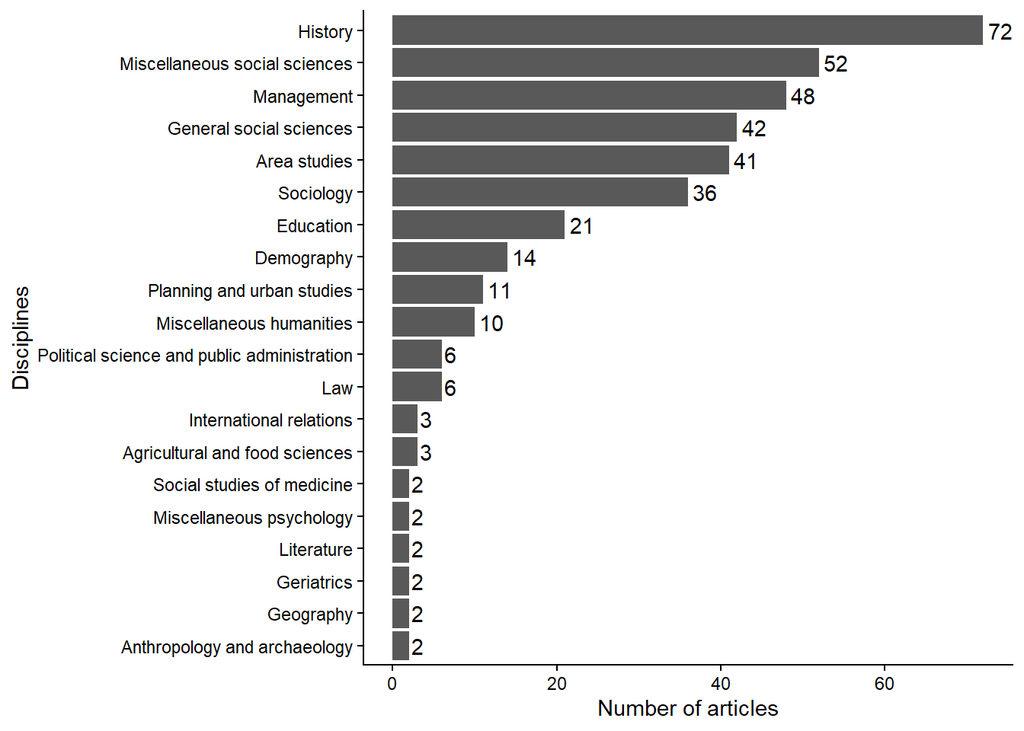

```r
# Plot figure

wos_publications %>%
  select(-author) %>%
  distinct() %>%
  group_by(specialties) %>%
  summarise(count = n()) %>%
  filter(!(specialties == "Economics")) %>%
  filter( count > 1) %>%
  ggplot(aes(y = fct_reorder(specialties, count), x = count)) +
  geom_col() +
  geom_text(aes(label = paste0(count), hjust = -0.2)) +
  theme_classic() +
  xlab("Number of articles") +
  ylab("Disciplines")
```

# Citation analysis using Web of Science databases

In this section we focus on references contained in the documents we described in the previous section.

The Web of Science is neither exhaustive nor perfect but at least the gaps and biases of the database are well identified (Archambault et al. 2009). For instance, one might complain that only journal articles are indexed in the database. However, this limit does not represent a major issue as, even if in social sciences the weight of research articles is less important than in fields like physics, specially before the 1990s (Larivière et al. 2006), articles published in scholarly journals represents, even before the 1990s, the vehicles *par excellence* for the circulation of knowledge validated by the scientific profession. Moreover, there is no reason to think that citations from books would be different than those from articles. In fact, Yves Gingras and Mahdi Khelfaoui (2019) analyzed citation patterns from different social sciences and humanity fields to show that there were no significant differences between rankings of authors whether they are cited in journals, books and book chapters. Finally, it must be noted that the papers contained in the journals indexed in the WoS cite thousands of different publication mediums, including books and book chapters, and not only the major journals which are represented in the database.

**Figure A5.** References per document (The curve is smoothed using local polynomial regression fitting)

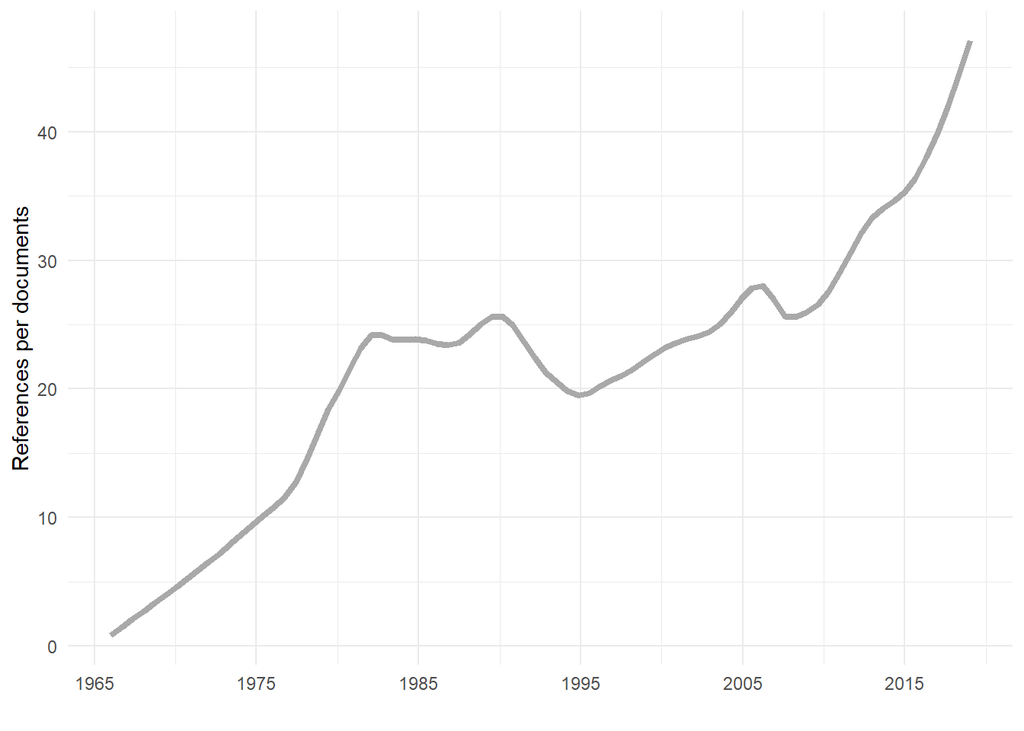

```r
# Load WoS data for citation analysis
wos_citations <- import(here("data", "wos_citations_2.csv"))

# Re-arranging data in different periods
wos_citations <- wos_citations %>%
  mutate(windows = case_when(
    between(Citing_Years, 1966, 1975) ~ "1966-1975",
    between(Citing_Years, 1976, 1985) ~ "1976-1985",
    between(Citing_Years, 1986, 1995) ~ "1986-1995",
    between(Citing_Years, 1996, 2005) ~ "1996-2005",
    between(Citing_Years, 2006, 2015) ~ "2006-2015",
    between(Citing_Years, 2016, 2019) ~ "2016-2019")
  )

# To remove self-citations
no_self_cit <- wos_citations %>%
  filter(!Citing_Authors == Cited_Authors)

# To manually remove remaining self_citations in cases of duplicates
no_self_cit <-
  no_self_cit %>%
  filter(!(Document_ID == "18096111" & Cited_Authors == "SHACKELFORD-JA")) %>%
  filter(!(Document_ID == "18096111" & Cited_Authors == "BARTLETT-RL")) %>%
  filter(!(Document_ID == "19702491" & Cited_Authors == "BENERIA-L")) %>%
  filter(!(Document_ID == "24379073" & Cited_Authors == "BERGMANN-BR")) %>%
  filter(!(Document_ID == "30814659" & Cited_Authors == "DOSS-CR")) %>%
  filter(!(Document_ID == "43848482" & Cited_Authors == "SEGUINO-S")) %>%
  filter(!(Document_ID == "48968233" & Cited_Authors == "KABEER-N")) %>%
  filter(!(Document_ID == "48968233" & Cited_Authors == "BENERIA-L")) %>%
  filter(!(Document_ID == "55892286" & Cited_Authors == "KABEER-N"))


# Total number of articles per years
art_yr <-
  wos_citations %>% # Some articles have only self-citations as references
  select(Document_ID, Citing_Years) %>%
  distinct() %>%
  count(Citing_Years, name = "art")

# Total number of references per years
ref_yr <- no_self_cit %>% # To eliminate self-citations
  count(Citing_Years, name = "ref")

# Number of references per articles
mean_ref_yr <- ref_yr %>%
  left_join(art_yr,
            join_by(Citing_Years)) %>%
  group_by(Citing_Years) %>%
  mutate(mean_ref = ref/art)

# Visualization
mean_ref_yr %>%
  ggplot(aes(y = mean_ref, x = Citing_Years)) +
  geom_smooth(se = FALSE, span = .3, color = "darkgrey", size = 1.5) +
  theme_minimal() +
  scale_x_continuous(breaks = seq(from = 1965, to = 2020, by = 10)) +
  xlab("") +
  ylab("References per documents")
```

**Figure A6.** Share of Self-citations by authors

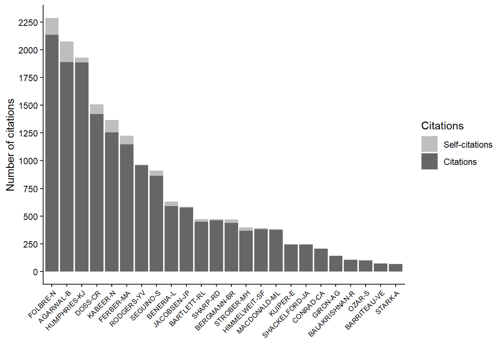

```r
# To visualize self-citations per authors over total references
wos_citations %>%
  ggplot(
    aes(
      x = fct_infreq(Citing_Authors),
      fill = !Citing_Authors == Cited_Authors
    )
  ) +
  geom_bar() +
  scale_y_continuous(breaks = seq(0, 2500, 250)) +
  theme_classic() +
  theme(
    axis.text.x = element_text(
      size = 7,
      angle = 45,
      hjust = 1
    )
  ) +
  scale_fill_manual(
    values = c(
      "FALSE" = "gray",
      "TRUE" = "gray40"
    ),
    labels = c(
      "FALSE" = "Self-citations",
      "TRUE" = "Citations"
    ),
    name = "Citations"
  ) +
  ylab("Number of citations") +
  xlab("")
```

**Figure A7.** IAFFE presidents citing most other IAFFE presidents (in percentage of the total of their references)

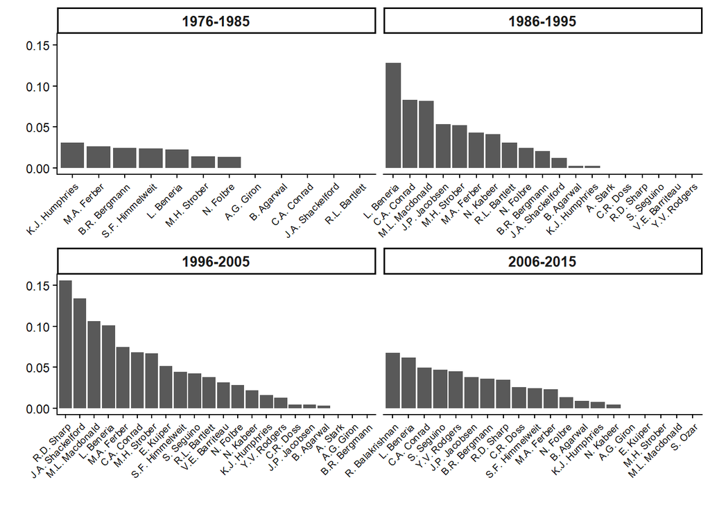

```r
# To select presidents cited by other presidents

pres_cit_pres <-
  no_self_cit %>%
  filter(
    Cited_Authors == "AGARWAL-B" |
    Cited_Authors == "BALAKRISHNAN-R" |
    Cited_Authors == "BARRITEAU-VE" |
    Cited_Authors == "BARTLETT-RL" |
    Cited_Authors ==  "BENERIA-L" |
    Cited_Authors == "BERGER-S" |
    Cited_Authors == "BERGMANN-BR" |
    Cited_Authors == "CONRAD-CA" |
    Cited_Authors == "DOSS-CR" |
    Cited_Authors == "FERBER-MA" |
    Cited_Authors == "FOLBRE-N" |
    Cited_Authors == "GIRON-AG" |
    Cited_Authors == "HIMMELWEIT-SF" |
    Cited_Authors == "HUMPHRIES-KJ" |
    Cited_Authors == "JACOBSEN-JP" |
    Cited_Authors == "KABEER-N" |
    Cited_Authors == "KUIPER-E" |
    Cited_Authors == "MACDONALD-ML" |
    Cited_Authors == "OZAR-S" |
    Cited_Authors == "RODGERS-YM" |
    Cited_Authors == "SEGUINO-S" |
    Cited_Authors == "SHACKELFORD-JA" |
    Cited_Authors == "SHARP-RD" |
    Cited_Authors == "STARK-A" |
    Cited_Authors =="STROBER-MH" |
    Cited_Authors == "TODARO-RC"
  )

# Plot Figure

pres_cit_pres1 <-
  pres_cit_pres %>%
  count(Citing_Authors, windows)

no_self_cit %>%
  count(Citing_Authors, windows) %>%
  group_by(Citing_Authors) %>%
  rename("total" = n) %>%
  left_join(
    pres_cit_pres1,
    join_by(
      Citing_Authors,
      windows
    )
  ) %>%
  mutate(proportion = n/total) %>%
  filter(
    windows != "1966-1975",
    windows != "2016-2019"
  ) %>%
  separate(
    Citing_Authors,
    into = c("name", "firstname"),
    sep = "-"
  ) %>%
  mutate(name = str_to_title(name)) %>%
  separate_wider_regex(
    firstname,
    patterns = c(
      initial1 = "[[A-Z]]+",
      "",
      initial2 = "[[A-Z]]+"
    ),
    too_few = "align_start") %>%
  mutate(
    initial1 = str_c(initial1, "", "."),
    initial2 = str_c(initial2, "", ".")
  ) %>%
  unite(
    firstname,
    c("initial1", "initial2"),
    sep = "",
    na.rm =TRUE
  ) %>%
  unite(
    Citing_Authors,
    c("firstname", "name"),
    sep = " "
  ) %>%
  ggplot(
    aes(
      x = reorder_within(
        Citing_Authors,
        -proportion,
        windows
      ),
      y = proportion
    )
  ) +
  geom_col() +
  theme_classic() +
  facet_wrap(
    ~windows,
    scales = "free_x",
    nrow = 2
  ) +
  theme(
    strip.text.x = element_text(
      size = 10,
      face = "bold"
    ),
    axis.text.x = element_text(
      size = 7,
      angle = 45,
      hjust = 1
    )
  ) +
  ylab("") +
  xlab("") +
  scale_x_reordered()
```

Networks were generated using the open-source software Gephi which comes with the “Atlas Force 2” algorithm that was applied to calculate the spatial location of each node (an author) in the network according to the intensity of the edges (the citations) it has with the other nodes in the network. The more two authors cite each other, the stronger the edge between them will be and so the closer they will appear on the network map.

In bibliometric literature it is generally advised to use time windows between five and ten years to analyze citations from social sciences given that the median age of cited literature in these fields is about five years and that articles published in social sciences reach their citation peak around ten years after their publication (Archambault and Larivière 2010). For that reason, we chose to focus on four time-windows of ten years each in our study: 1976-1985, 1986-1995, 1996-2005 and 2006-2015.

```r
#

input <-
  pres_cit_pres %>%
  select(
    Source = Citing_Authors,
    Target = Cited_Authors,
    windows
  )
```

## 1976-1985

**Figure 1.** Direct citations network of IAFFE presidents, 1976-1985 (The size of the nodes and edges being proportional to the number of citations)

```r
# Export datatables for Gephi

input %>%
  filter(windows == "1976-1985") %>%
  select(Source, Target) %>%
  mutate(Weight = "1", Type = "Directed") %>%
  export(
    here(
      "data",
      "citation_analysis",
      "input_7685.csv"
    ),
    format = ","
  )
```

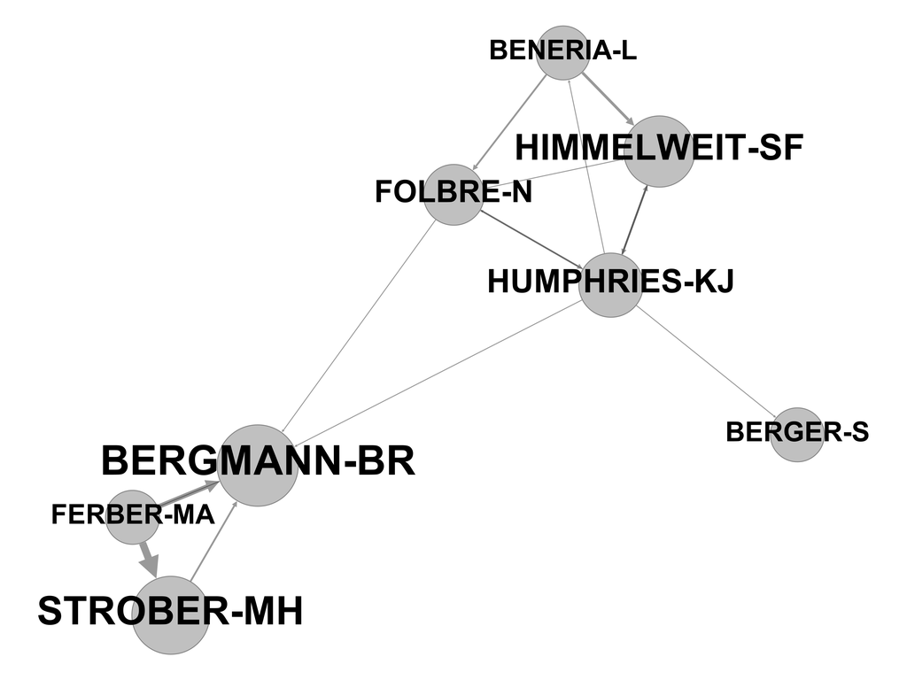

**Table A4.**

```r
# Import data with degree of centrality measures

central_authors_7685 <-
  import(
    here(
      "data",
      "citation_analysis",
      "centrality_1976_1985.csv"
    )
  )

# Table layout

central_authors_7685 %>%
  select(
    Label,
    degree,
    weighted_degree,
    indegree,
    weighted_indegree,
    outdegree,
    weighted_outdegree
  ) %>%
  arrange(desc(weighted_outdegree)) %>%
  ## Comment for docx format
  datatable(
    options = list(paging = FALSE, scrollY = 300),
    rownames = FALSE
  )
```

| Label | degree | weighted_degree | indegree | weighted_indegree | outdegree | weighted_outdegree |
| --- | --- | --- | --- | --- | --- | --- |
| FERBER-MA | 3 | 0,943995 | 1 | 0,204545 | 2 | 0,73945 |
| HUMPHRIES-KJ | 7 | 0,369721 | 2 | 0,130915 | 5 | 0,238806 |
| BERGMANN-BR | 5 | 0,706125 | 4 | 0,50158 | 1 | 0,204545 |
| BENERIA-L | 3 | 0,230479 | 1 | 0,039801 | 2 | 0,190678 |
| STROBER-MH | 2 | 0,612941 | 1 | 0,455046 | 1 | 0,157895 |
| HIMMELWEIT-SF | 4 | 0,305443 | 3 | 0,213489 | 1 | 0,091954 |
| FOLBRE-N | 5 | 0,193994 | 2 | 0,116072 | 3 | 0,077922 |
| BERGER-S | 1 | 0,039801 | 1 | 0,039801 | 0 | 0 |

```r
  ## Uncomment for docx format
  # flextable() %>%
  # set_table_properties(width = 1, layout = "autofit") %>%
  # fontsize(size = 9, part = "all") %>%
  # bold(bold = TRUE, part = "header") %>%
  # padding(padding.bottom = 3, part = "all")
```

## 1986-1995

**Figure 2.** Direct citations network of IAFFE presidents, 1986-1995 (The size of the nodes and edges being proportional to the number of citations)

```r
# Export datatables for Gephi

input %>%
  filter(windows == "1986-1995") %>%
  select(Source, Target) %>%
  mutate(Weight = "1", Type = "Directed") %>%
  export(
    here(
      "data",
      "citation_analysis",
      "input_8695.csv"
    ),
    format = ","
  )
```

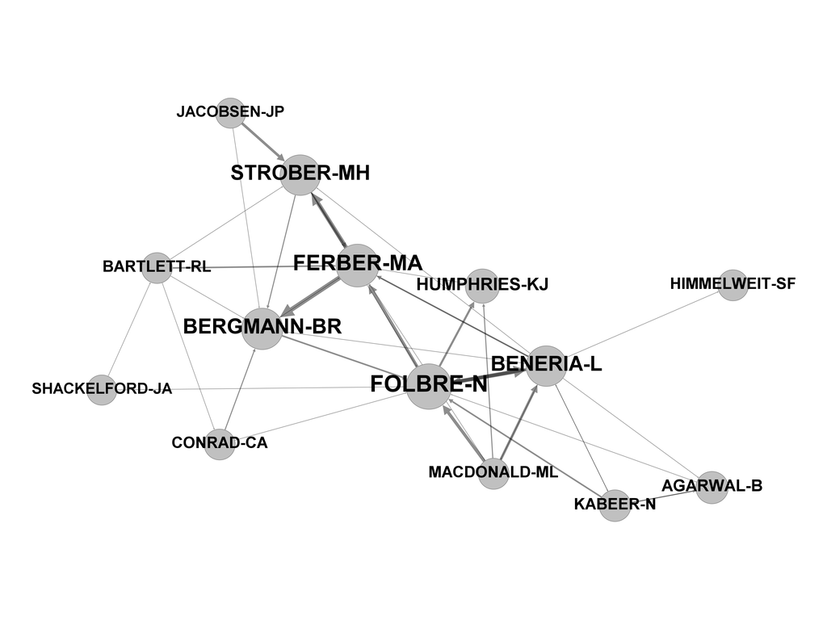

**Table A5.**

```r
# Import data with degree of centrality measures

central_authors_8695 <-
  import(
    here(
      "data",
      "citation_analysis",
      "centrality_1986_1995.csv"
    )
  )

# Table settings

central_authors_8695 %>%
  select(
    Label,
    degree,
    weighted_degree,
    indegree,
    weighted_indegree,
    outdegree,
    weighted_outdegree
  ) %>%
  ## Comment for docx format
  arrange(desc(weighted_outdegree)) %>%
  datatable(
    options = list(paging = FALSE, scrollY = 300),
    rownames = FALSE
  )
```

| Label | degree | weighted_degree | indegree | weighted_indegree | outdegree | weighted_outdegree |
| --- | --- | --- | --- | --- | --- | --- |
| FERBER-MA | 10 | 1,76911 | 7 | 0,778284 | 3 | 0,990826 |
| JACOBSEN-JP | 2 | 0,789474 | 0 | 0 | 2 | 0,789474 |
| FOLBRE-N | 11 | 1,689487 | 8 | 1,043333 | 3 | 0,646154 |
| BENERIA-L | 12 | 1,044571 | 4 | 0,467648 | 8 | 0,576923 |
| BERGMANN-BR | 8 | 1,382034 | 6 | 0,989511 | 2 | 0,392523 |
| STROBER-MH | 7 | 1,540268 | 4 | 1,171037 | 3 | 0,369231 |
| SHACKELFORD-JA | 2 | 0,284024 | 0 | 0 | 2 | 0,284024 |
| CONRAD-CA | 3 | 0,284314 | 1 | 0,034314 | 2 | 0,25 |
| MACDONALD-ML | 5 | 0,279841 | 1 | 0,038462 | 4 | 0,241379 |
| KABEER-N | 5 | 0,283948 | 2 | 0,048654 | 3 | 0,235294 |

[output cut: 4 more lines]

```r
  ## Uncomment for docx format
  # flextable() %>%
  # set_table_properties(width = 1, layout = "autofit") %>%
  # fontsize(size = 9, part = "all") %>%
  # bold(bold = TRUE, part = "header") %>%
  # padding(padding.bottom = 3, part = "all")
```

## 1996-2005

**Figure 3.** Direct citations network of IAFFE presidents, 1996-2005 (The size of the nodes and edges being proportional to the number of citations)

```r
# Export datatables for Gephi

input %>%
  filter(windows == "1996-2005") %>%
  select(Source, Target) %>%
  mutate(Weight = "1", Type = "Directed") %>%
  export(
    here(
      "data",
      "citation_analysis",
      "input_9605.csv"
    ),
    format = ","
  )
```

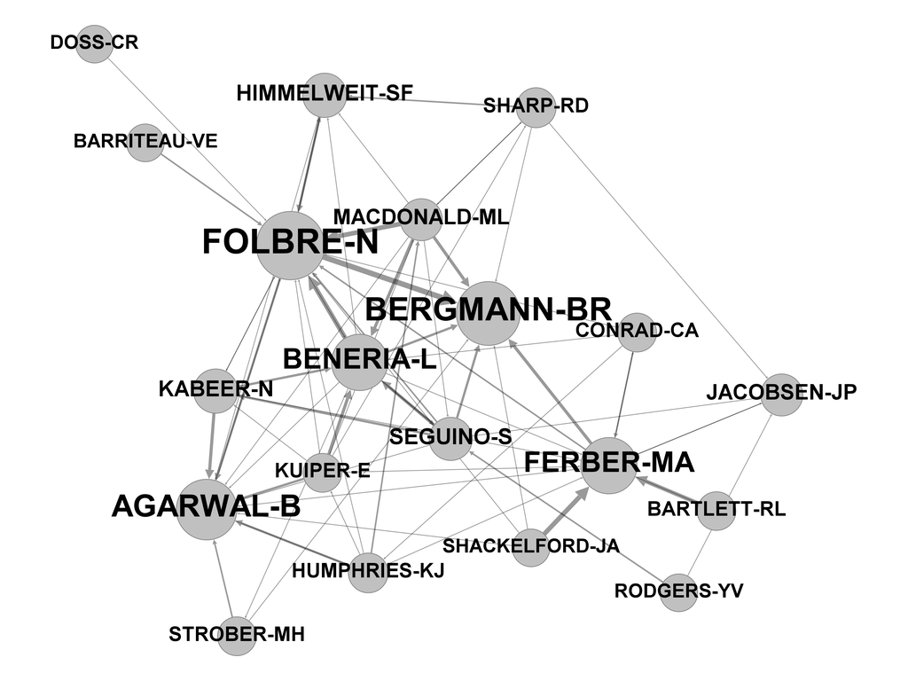

**Table A6.**

```r
# Import data with degree of centrality measures

central_authors_9605 <-
  import(
    here(
      "data",
      "citation_analysis",
      "centrality_1996_2005.csv"
    )
  )

# Table settings

central_authors_9605 %>%
  select(
    Label,
    degree,
    weighted_degree,
    indegree,
    weighted_indegree,
    outdegree,
    weighted_outdegree
  ) %>%
  arrange(desc(weighted_outdegree)) %>%
  ## Comment for docx format
  datatable(
    options = list(paging = FALSE, scrollY = 300),
    rownames = FALSE
  )
```

| Label | degree | weighted_degree | indegree | weighted_indegree | outdegree | weighted_outdegree |
| --- | --- | --- | --- | --- | --- | --- |
| FERBER-MA | 14 | 2,15128 | 7 | 0,993386 | 7 | 1,157895 |
| CONRAD-CA | 5 | 0,927181 | 1 | 0,105263 | 4 | 0,821918 |
| MACDONALD-ML | 10 | 0,917394 | 3 | 0,184836 | 7 | 0,732558 |
| BENERIA-L | 13 | 1,153309 | 6 | 0,583689 | 7 | 0,56962 |
| FOLBRE-N | 18 | 1,885492 | 13 | 1,356192 | 5 | 0,529301 |
| SHARP-RD | 6 | 0,443945 | 2 | 0,049208 | 4 | 0,394737 |
| HUMPHRIES-KJ | 7 | 0,572468 | 2 | 0,182955 | 5 | 0,389513 |
| SHACKELFORD-JA | 4 | 0,375 | 0 | 0 | 4 | 0,375 |
| STROBER-MH | 3 | 0,405322 | 1 | 0,037975 | 2 | 0,367347 |
| HIMMELWEIT-SF | 6 | 0,652607 | 4 | 0,312181 | 2 | 0,340426 |

[output cut: 10 more lines]

```r
  ## Uncomment for docx format
  # flextable() %>%
  # set_table_properties(width = 1, layout = "autofit") %>%
  # fontsize(size = 9, part = "all") %>%
  # bold(bold = TRUE, part = "header") %>%
  # padding(padding.bottom = 3, part = "all")
```

## 2006-2015

**Figure 4.** Direct citations network of IAFFE presidents, 2006-2015 (The size of the nodes and edges being proportional to the number of citations)

```r
# Export datatables for Gephi

input %>%
  filter(windows == "2006-2015") %>%
  select(Source, Target) %>%
  mutate(Weight = "1", Type = "Directed") %>%
  export(
    here(
      "data",
      "citation_analysis",
      "input_0615.csv"
    ),
    format = ","
  )
```

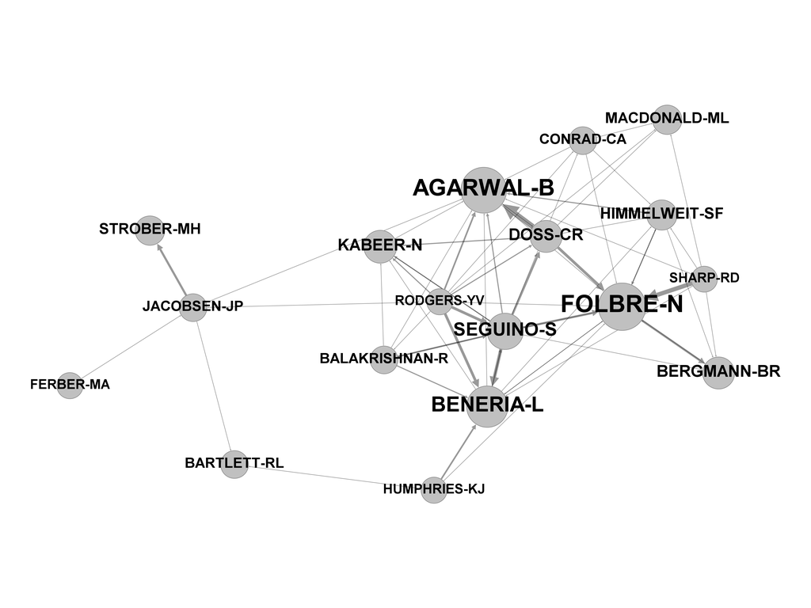

**Table A7.**

```r
# Import data with degree of centrality measures

central_authors_0615 <-
  import(
    here(
      "data",
      "citation_analysis",
      "centrality_2006_2015.csv"
    )
  )

# Table settings

central_authors_0615 %>%
  select(
    Label,
    degree,
    weighted_degree,
    indegree,
    weighted_indegree,
    outdegree,
    weighted_outdegree
  ) %>%
  arrange(desc(weighted_outdegree)) %>%
  ## Comment for docx format
  datatable(
    options = list(paging = FALSE, scrollY = 300),
    rownames = FALSE
  )
```

| Label | degree | weighted_degree | indegree | weighted_indegree | outdegree | weighted_outdegree |
| --- | --- | --- | --- | --- | --- | --- |
| RODGERS-YV | 10 | 0,61477 | 0 | 0 | 10 | 0,61477 |
| BERGMANN-BR | 5 | 0,622426 | 4 | 0,189093 | 1 | 0,433333 |
| DOSS-CR | 8 | 0,569493 | 3 | 0,154326 | 5 | 0,415167 |
| SEGUINO-S | 13 | 0,804025 | 5 | 0,410275 | 8 | 0,39375 |
| SHARP-RD | 6 | 0,343008 | 0 | 0 | 6 | 0,343008 |
| BENERIA-L | 11 | 0,81481 | 6 | 0,475187 | 5 | 0,339623 |
| JACOBSEN-JP | 5 | 0,290762 | 2 | 0,06716 | 3 | 0,223602 |
| FOLBRE-N | 14 | 1,266324 | 10 | 1,047574 | 4 | 0,21875 |
| BALAKRISHNAN-R | 6 | 0,242956 | 2 | 0,046694 | 4 | 0,196262 |
| HUMPHRIES-KJ | 3 | 0,182094 | 0 | 0 | 3 | 0,182094 |

[output cut: 8 more lines]

```r
  ## Uncomment for docx format
  # flextable() %>%
  # set_table_properties(width = 1, layout = "autofit") %>%
  # fontsize(size = 9, part = "all") %>%
  # bold(bold = TRUE, part = "header") %>%
  # padding(padding.bottom = 3, part = "all")
```

# References

Archambault E. and Larivière V. 2010. “The Limits of Bibliometrics for the Analysis of the Social Sciences and Humanities Literature”, in Bokova I., Sané P. and Hernes G. (eds) *The World Social Science Report: Knowledge Divides*, Paris: Unesco: 251-254

Archambault E., Campbell D., Gingras Y. and Larivière V., 2009, “Comparing Bibliometric Statistics Obtained From the Web of Science and Scopus”, *Journal of the American Society for Information Science and Technology*, 60, 7: 1320-1326

Jacomy M., Venturini T., Heymann S. and Bastian M., 2014, “ForceAtlas2, A Continuous Graph Layout Algorithm for Handy Network Visualization Designed for the Gephi Software”, *PLOS One*, 9, 6

Larivière V., Archambault E., Gingras Y. and Vignola-Gagné E., 2006, “The Place of Serials in Referencing Practices: Comparing Natural Sciences and Engineering With Social Sciences and Humanities”, *Journal of the American Society for Information Science and Technology*, 57, 8: 997-1004

National Science Board, 2006 (vol. 2), *Science and Engineering Indicators 2006, Arlington*, VA: National Science Foundations

Svorenčík, A., 2018, “The Missing Link: Prosopography in the History of Economics.” *History of Political Economy*, 50, 3: 605-613